# Problem Set 4

Author

Liam Zamora Fields

Published

November 20, 2026

**GitHub repo:** https://github.com/lzamoraf04/ec422_ps4_LiamZamoraFields.git

## ARIMA vs ETS

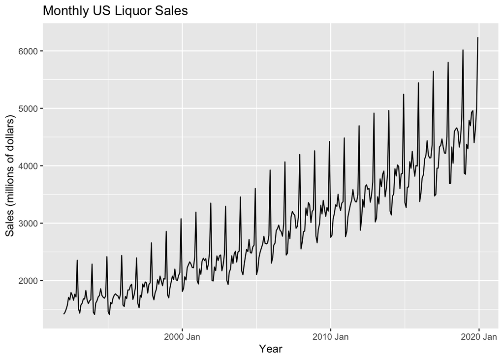

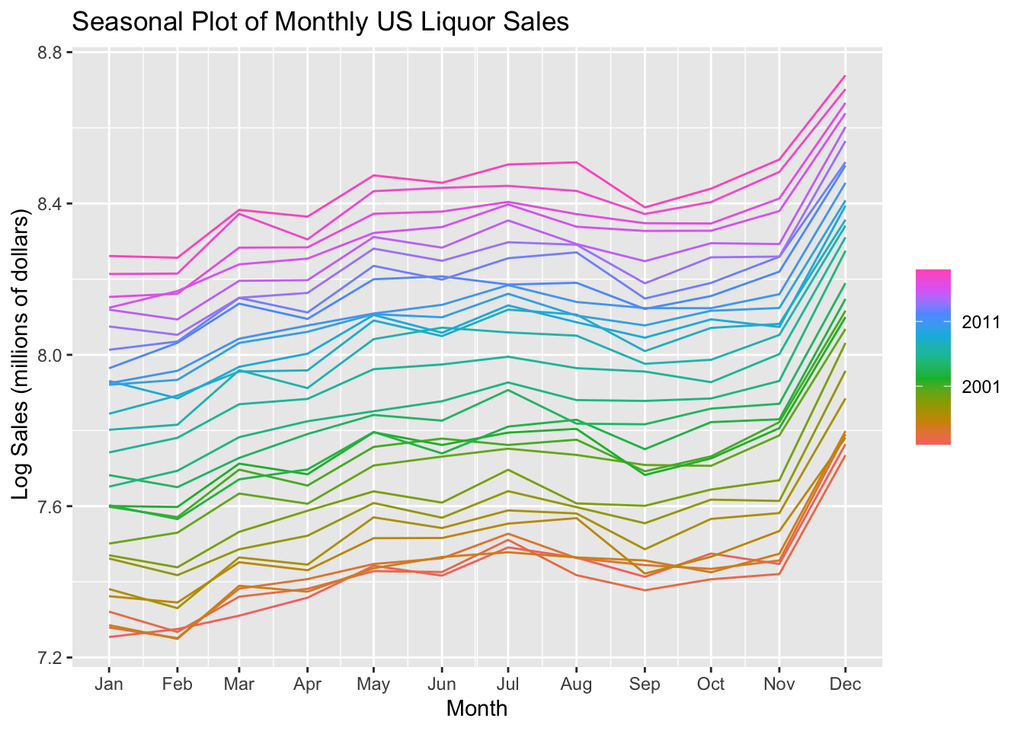

There is clearly an upwards trend in monthly US liqor sales, along with a seasonal pattern. The summer months have high alcohol sales, but December has the highest sales. The seasonal swings are growing with the level, so using logs would be appropriate.

```
Series: sales
Model: ARIMA(1,0,2)(2,1,1)[12] w/ drift
Transformation: log(sales)

Coefficients:
         ar1      ma1     ma2    sar1     sar2     sma1  constant
      0.8948  -0.7374  0.2477  0.3679  -0.2334  -0.8845    0.0036
s.e.  0.0355   0.0697  0.0623  0.0668   0.0665   0.0468    0.0001

sigma^2 estimated as 0.0005469:  log likelihood=752.43
AIC=-1488.85   AICc=-1488.4   BIC=-1458.61
```

```
Series: sales
Model: ETS(A,A,A)
Transformation: log(sales)
  Smoothing parameters:
    alpha = 0.3296099
    beta  = 0.007560263
    gamma = 0.0001765132

  Initial states:
     l[0]         b[0]      s[0]      s[-1]        s[-2]       s[-3]      s[-4]
 7.412219 0.0007608238 0.3263441 0.03153301 -0.004849389 -0.03530501 0.02512163
      s[-5]      s[-6]      s[-7]       s[-8]      s[-9]     s[-10]     s[-11]
 0.05558624 0.01219515 0.02503206 -0.06088935 -0.0607952 -0.1578065 -0.1561667

  sigma^2:  7e-04

      AIC      AICc       BIC
-489.1517 -487.2272 -424.2608
```

ARIMA: It chose an ARIMA(1,0,2)(2,1,1)[12] model with drift. This means that it chose one seasonal difference. Two seasonal lags are used for the autoregressive part, and one seasonal lag is used for the moving average part. It chose to do no additional differencing, and it chose to use two non-seasonal moving average lags and one non-seasonal autoregressive lag.

ETS: R specified additive error, trend, and seasonal components on the logged series. It produced a small beta and gamma, meaning that changes in trend and seasonal swings are fairly constant.

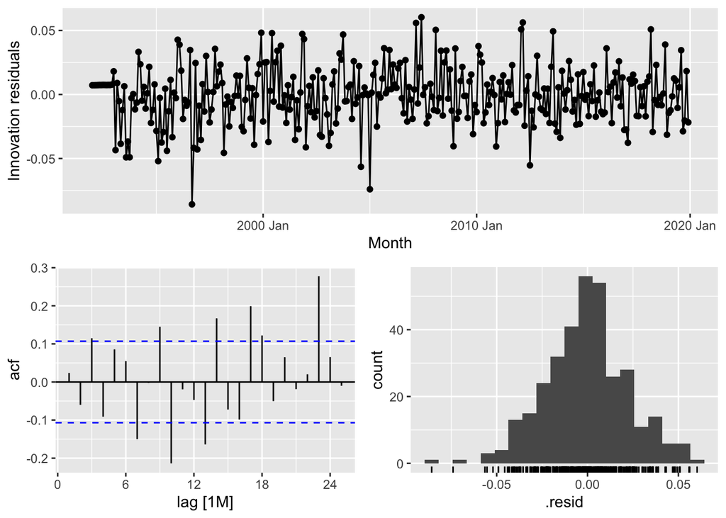

```
# A tibble: 1 × 3
  .model lb_stat lb_pvalue
  <chr>    <dbl>     <dbl>
1 arima     120.         0
```

The residuals do not look like white noise. Reject the null of the ljung-box test at pvalue 0.

216 forecast origins were considered for this TSCV.

| .model | .type | RMSE | MAE |
| --- | --- | --- | --- |
| arima | Test | 81.43 | 65.65 |
| ets | Test | 94.35 | 72.31 |
| snaive | Test | 161.26 | 136.63 |

First Month: Jan 2002 Last month: December 2019

The ARIMA model is the better model. Both RMSE and MAE are lower.

```
    Diebold-Mariano Test

data:  liquor_errs$arimaliquor_errs$ets
DM = -2.9062, Forecast horizon = 1, Loss function power = 2, p-value =
0.004042
alternative hypothesis: two.sided
```

```
    Diebold-Mariano Test

data:  liquor_errs$arimaliquor_errs$snaive
DM = -10.755, Forecast horizon = 1, Loss function power = 2, p-value <
2.2e-16
alternative hypothesis: two.sided
```

ARIMA vs ETS: DM = -2.90, p-val = 0.0040

ARIMA vs SNAIVE: DM = -10.755, p-val = ~0.000

I would chose the ARIMA model, as it performs better by the metric of RMSE and MAE, and the DM test shows that the ARIMA model is significantly better than both ETS and SNAIVE.

## Forecast Combination

| .model | .type | RMSE | MAE |
| --- | --- | --- | --- |
| arima | Test | 81.43 | 65.65 |
| combo | Test | 85.19 | 66.77 |
| ets | Test | 94.35 | 72.31 |
| snaive | Test | 161.26 | 136.63 |

the combination is better than ETS on its own, but worse than ARIMA.

```r
cor(liquor_errs$arima, liquor_errs$ets)
```

```
[1] 0.8782932
```

There is large correlation between the errors of ETS and ARIMA. If we could optimally deal with this I would use covariance to reduce the size of a weight. Because the ETS model is significantly worse than the ARIMA model via DM test, I would conclude equal weights is a bad way to combine these two models.

## BAR vs BVAR

There will be 120 forcasts. The first will be Q1 1990 and the last will be Q4 2019

```
      gdp      cons       inv       emp      infl    unrate       ffr      gs10
0.5130384 0.4598547 2.4927057 0.1956584 0.2084055 0.1988068 0.3902989 0.3610310
```

```
      gdp      cons       inv       emp      infl    unrate       ffr      gs10
0.5693241 0.5268484 2.5212629 0.2277561 0.2069608 0.2153966 0.4973504 0.3789663
```

The VAR(1) forecasts better for 7 of the 8 variables. VAR(4) only does better on inflation. The smaller model does better because the larger model is likely overfitting.

| Variable | VAR(1) | VAR(4) | BVAR(4), lambda = 0.3 | BVAR(4), lambda = 0.05 |
| --- | --- | --- | --- | --- |
| gdp | 0.513 | 0.569 | 0.539 | 0.567 |
| cons | 0.460 | 0.527 | 0.486 | 0.495 |
| inv | 2.493 | 2.521 | 2.385 | 2.698 |
| emp | 0.196 | 0.228 | 0.211 | 0.315 |
| infl | 0.208 | 0.207 | 0.197 | 0.330 |
| unrate | 0.199 | 0.215 | 0.203 | 0.216 |
| ffr | 0.390 | 0.497 | 0.414 | 0.358 |
| gs10 | 0.361 | 0.379 | 0.359 | 0.362 |

1)The BVAR(4) with lam=0.3 performs better than the OLS VAR(4) for all variables. The Minnesota prior has the effect of making more distant lags matter less, which has improved the accuracy of the model. The parameters also get shrunk towards 0.

3)The BVAR(4) with lam=0.05 performs worse than the BVAR(4) lam=0.3 for all variable but one. There may be too much shrinkage with a lamda that small. RMSE is a fair estimate of how accurately it will forecast in the future assuming future data looks like the data in the test period.

```
    Diebold-Mariano Test

data:  e_var4e_bvar
DM = 2.1366, Forecast horizon = 1, Loss function power = 2, p-value =
0.03468
alternative hypothesis: two.sided
```

```
    Diebold-Mariano Test

data:  e_var5e_bvar1
DM = 3.0264, Forecast horizon = 1, Loss function power = 2, p-value =
0.003034
alternative hypothesis: two.sided
```

I reject the null that BVAR(4) and VAR(4) have equal forecast accuracy for GDP or consumption growth. It doesn’t really change my thinking from 4.3b.

## Factor Model

```
[1] 718 122
```

```
  INDPRO   PAYEMS CPIAUCSL FEDFUNDS
       5        5        6        2
```

INDPRO and PAYEMS were transformed to growth rates. CPI was transformed to change in growth rate and FEDFUNDS was transformed to first difference.FEDFUNDS doesn’t have a trend, whereas INDPRO does. FEDFUNDS is probably auto correlated, so a difference makes sense.

```
                            PC1      PC2      PC3      PC4      PC5
Standard deviation     4.258002 2.993839 2.923106 2.597224 2.295261
Proportion of Variance 0.149840 0.074070 0.070620 0.055750 0.043540
Cumulative Proportion  0.149840 0.223910 0.294530 0.350280 0.393820
```

The first three principal components account for 29.4% of the variation.

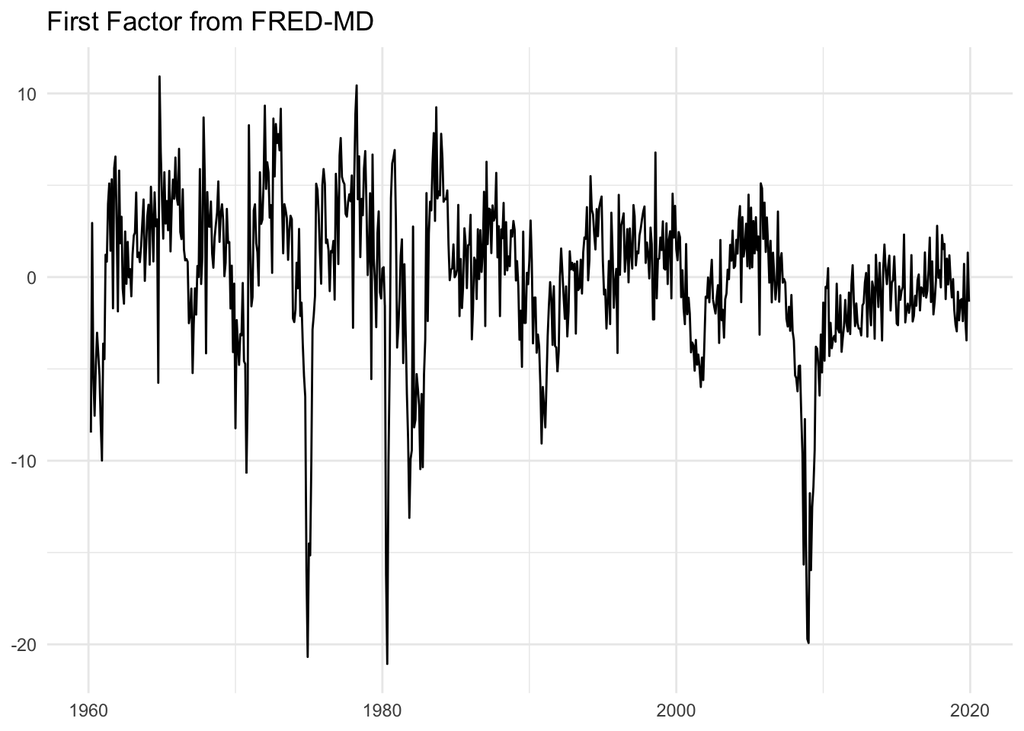

```
   PAYEMS IPMANSICS    USGOOD    INDPRO    MANEMP   IPFPNSS    CUMFNS   DMANEMP
0.8415788 0.8404473 0.8390159 0.8219976 0.8028499 0.7903078 0.7778686 0.7768615
```

```
    CUSR0000SAC DNDGRG3M086SBEA   CUSR0000SA0L2        CPIAUCSL   CUSR0000SA0L5
      0.7468587       0.7391330       0.7279202       0.7198020       0.7020307
       CPITRNSL           PCEPI        CPIULFSL
      0.6806883       0.6795890       0.6570361
```

```
  RMSE_AR   RMSE_FA
0.6168431 0.5887272
```

Yes, i got the same numbers. It would be cheating to estimate the full factors because you would be encoding future information into your model. In a non-testing environment you don’t have future data.

```
# A tibble: 1 × 7
  series   forecasts RMSE_AR RMSE_FA MAE_AR MAE_FA DM_pvalue
  <chr>        <int>   <dbl>   <dbl>  <dbl>  <dbl>     <dbl>
1 CPIAUCSL       349    2.11    1.89   1.58   1.35  0.000443
```